# digiRhythm demo

This notebook showcases the use of the [digiRhythm package](https://cran.r-project.org/web/packages/digiRhythm/index.html).

is an R package for the analysis of animal activity during night and day. The package was written by Dr. Roland Nasser and an description of the project can be found at [DigiRhythm](https://www.agroscope.admin.ch/agroscope/en/home/topics/economics-technology/smart-farming/digirhythm.html)

In this package we will explore a sample dataset of this package and showcase the different plots that the pacakge offers.

## Setup

Load the package

```r
install.packages("devtools")
install.packages('digiRhythm', dependencies = T)
```

## Load the data

Here we are loading an example dataset provided by the package. The package provides promises to fetch the data: so for this notebook we will use this promise to avoid downloading the dataset.

The dataset contains the observations of one animal and tracks it’s activity index and steps over time: the observations are recorded evers 15 minutes.

```r
library(digiRhythm)

# Select an input file containing position recordings over time.
filename <- here::here('data', '516b_2.csv')

#The columns that we are interested in
colstoread <- c("Date", "Time", "Motion Index", 'Steps')

# Reading the activity data from the csv file
df <- import_raw_activity_data(
  filename = filename,
  skipLines = 7,
  act.cols.names = colstoread,
  sampling = 15)
```

## Inspect the data

The dataset can be inspected by the `is_dgm_friendly` function: it checks whether the observations have the expected attributes and frequencies.

```r
is_dgm_friendly(df, verbose=T)
```

```
## v Correct time format: First column has a POSIXct Format
## v Number of days: Bigger or equal to 7
## v Correct numeric format - Column 2 ==> Motion.Index
## v Correct numeric format - Column 3 ==> Steps
## The data is digiRhythm friendly
```

```
## [1] TRUE
```

Metadata such as the time period that was monitored is provided by the function `df_act_info`.

```r
df_act_info(df)
```

```
## [1] "First days of the data set: "
##              datetime Motion.Index Steps
## 1 2020-05-01 00:00:00            0     0
## 2 2020-05-01 00:15:00            7     0
## 3 2020-05-01 00:30:00            3     0
## 4 2020-05-01 00:45:00           39    13
## 5 2020-05-01 01:00:00           37    16
## 6 2020-05-01 01:15:00           33    14
## [1] "Last days of the data set: "
##                 datetime Motion.Index Steps
## 4315 2020-06-14 22:30:00          100    39
## 4316 2020-06-14 22:45:00            8     5
## 4317 2020-06-14 23:00:00            6     4
## 4318 2020-06-14 23:15:00           86    29
## 4319 2020-06-14 23:30:00            4     0
## 4320 2020-06-14 23:45:00            0     0
## [1] "The dataset contains 46 Days"
## [1] "Starting date is: 2020-04-30"
## [1] "Last date is: 2020-06-14"
```

## Visualization

Specific visualizations are also provided, with an option to directly save the figure to a file.

### Activity over time

First, the `actogram` function shows activity along the day for all dates at the same time, as a heatmap. This function allows to specify a column to visualize, a date range to include. When we are satisfied with the figure, we can save it by giving a file path with the `save` option.

For this animal we can see that the activity is very regular and peeks in the morning and evening.

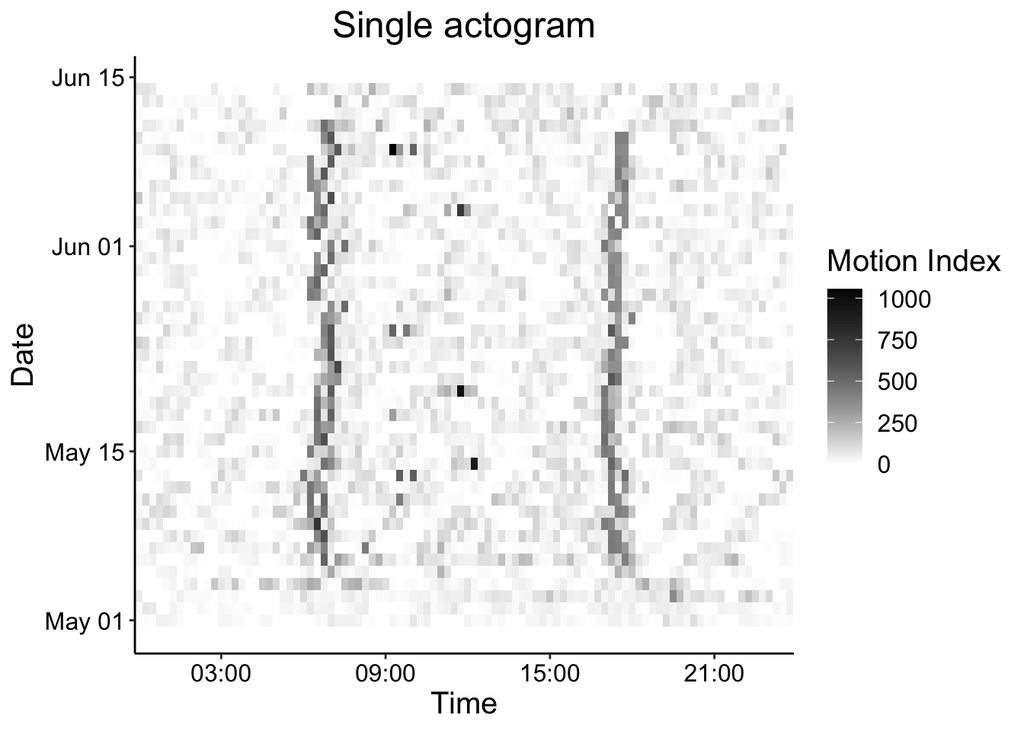

```r
# Define time range to include in figures
start <- '2020-04-30'
end <- '2020-06-14'

p <- actogram(df,
         activity = 'Motion.Index',
         activity_alias = 'Motion Index',
         start = start,
         end = end,
         save = NULL)
```

`daily_average_activity` provides an alternative visualization where observation are grouped by the time of day the curve shows the mean activity on a given time of the day. The function allows for chosing a time period for the grouping of the observations: it looks at the average activity during a day in a given time interval.

Again we can see that in the chosen time interval the activity peeks in the morning and in the evening.

```r
p <- daily_average_activity(df,
         activity = 'Motion.Index',
         activity_alias = 'Motion Index',
         start = start,
         end = end,
         save = NULL)
```

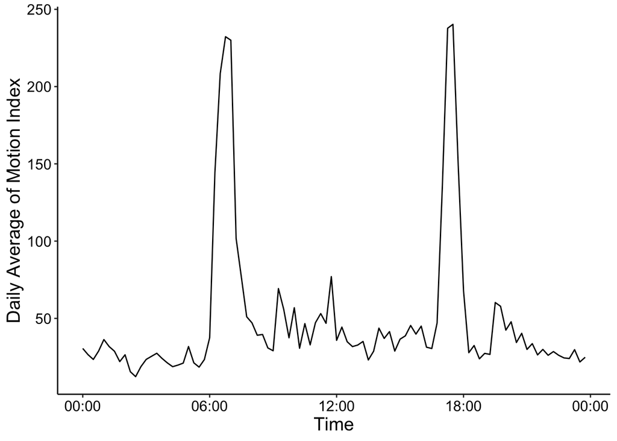

All plotting functions in digiRhythm return ggplot2 objects. We can therefore customize the way we display them: here below we are adding a title and print out the start and end date of the observation that were grouped and aggregated.

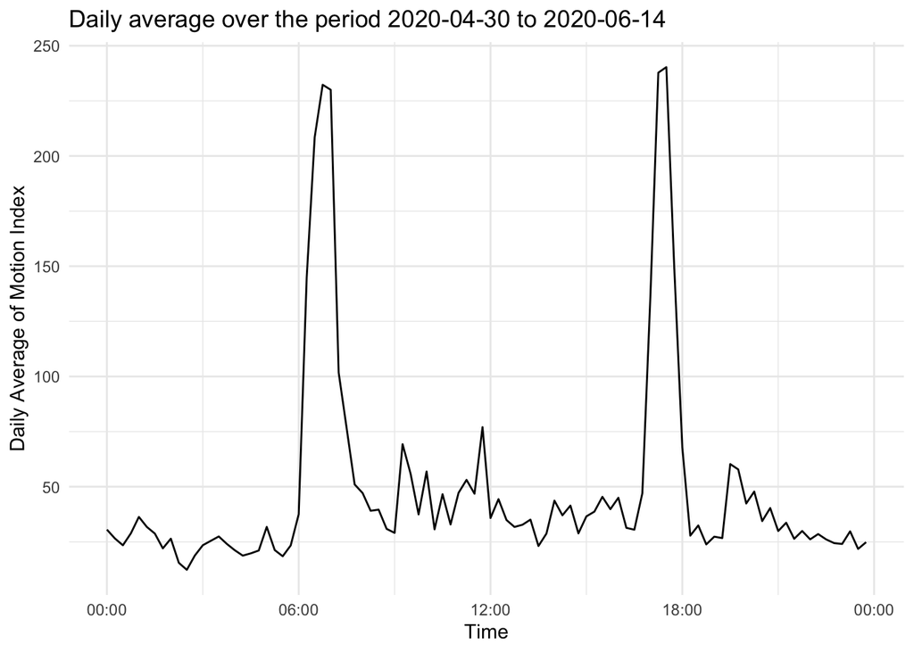

```r
library(ggplot2)
title <- sprintf(
  "Daily average over the period %s to %s",
  start,
  end
  )
p +
  theme_minimal() +
  ggtitle(title)
```

### Periodicity

Initially the time between observations is 15 Minutes: we can confirm this by printing out the periodictiy of the dataset.

```r
dgm_periodicity(df)
```

```
## 15 minute periodicity from 2020-05-01 to 2020-06-14 23:45:00
```

### Diurnality

The `diurnality` function computes and plots the diurnality index over the year, computed as $\frac{A_d - A_n}{A_d+A_n}$ where $A_d$ and $A_n$ is the total activity during day and night, respectively. A positive diurnality index means that the animal is more active during the day than night.

```r
diur <- diurnality(df, activity = 'Steps')
```

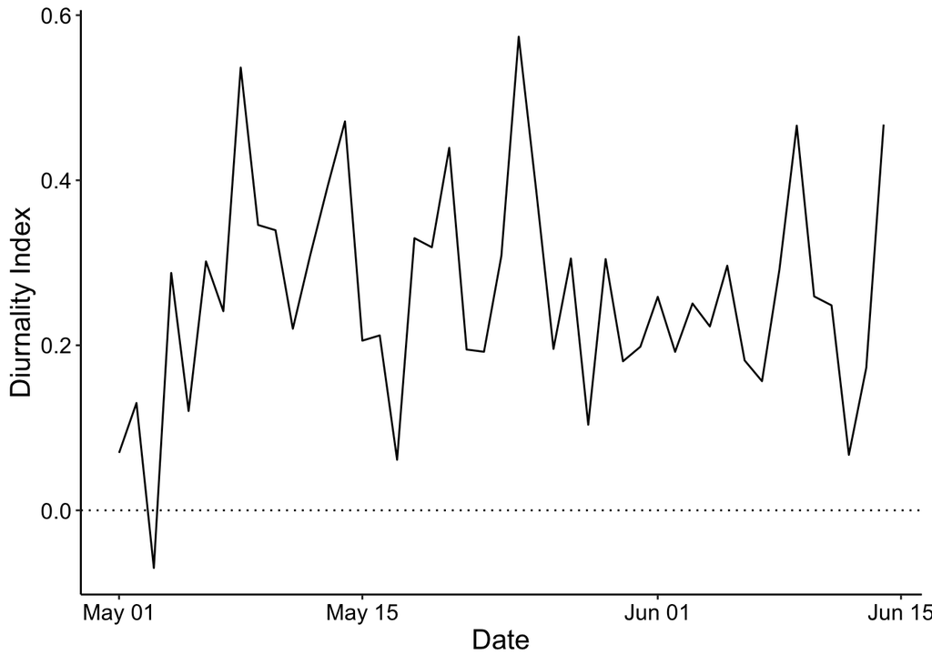